# til_ohjelmointi_htyo

Juha Kavka

29 10 2019

Luetaan ensin aineisto kahdeksi tauluksi. Yhdistetään data yhdeksi tauluksi ja muutetaan pitkä formaatti leveäksi formaatiksi. Lataan tarvittavat R- paketit. Muutetaan species- muuttuja faktoriksi

```r
data1=read.table("kurjenmiekka_mittaukset.csv",header = T ,sep = ",")
data2=read.table("kurjenmiekka_lajit.csv",header = T ,sep = ",")

data1$species <- data1$species_id
data1$species[data1$species=='1'] <- toString(data2$Species[1])
data1$species[data1$species=='2'] <- toString(data2$Species[2])
data1$species[data1$species=='3'] <- toString(data2$Species[3])


library(tidyverse)
library(tidyr)

data <- spread(data1,var,val)
data$species<- as.factor(data$species)

attach(data)
```

Sovitetaan lineaarinen malli aineistoon. Mallinnetaan verholehden leveyttä (Sepal.Width) selittävänä muuttujana verholehden pituus (Sepal.Legth).

```r
lm1 <- lm(Sepal.Width~Sepal.Length)
summary(lm1)
```

```
##
## Call:
## lm(formula = Sepal.Width ~ Sepal.Length)
##
## Residuals:
##     Min      1Q  Median      3Q     Max
## -1.1095 -0.2454 -0.0167  0.2763  1.3338
##
## Coefficients:
##              Estimate Std. Error t value Pr(>|t|)
## (Intercept)   3.41895    0.25356   13.48   <2e-16 ***
## Sepal.Length -0.06188    0.04297   -1.44    0.152
## ---
## Signif. codes:  0 '***' 0.001 '**' 0.01 '*' 0.05 '.' 0.1 ' ' 1
##
## Residual standard error: 0.4343 on 148 degrees of freedom
## Multiple R-squared:  0.01382,    Adjusted R-squared:  0.007159
## F-statistic: 2.074 on 1 and 148 DF,  p-value: 0.1519
```

Tulostuksesta nähdään, että Sepal.Legth ei ole tilastollisesti merkitsevä selittäjä mallissa (p-arvo 0.152). Sepal.Legth muuttujan estimaatti on -0.06188. Selittäjällä on negatiivinen korrelaatio vastemuuttujaan, verholehden pituuden kasvessa verholehden leveys lyhenee. Mallin korjattu selitysaste (adjusted R-squared) on vain 0.007.

Piirretään kuvaaja, jossa x = Sepal.Length ja y = Sepal.Width.

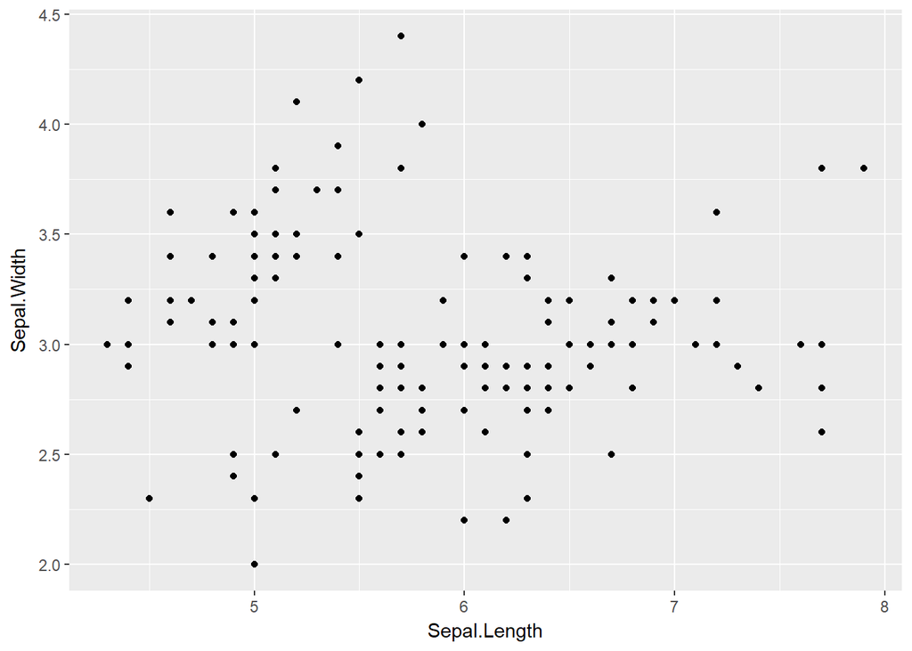

```r
ggplot(data = data) +
  geom_point(mapping = aes(x = Sepal.Length, y = Sepal.Width))
```

Seuraavaksi piirretään kuvaaja, jossa x = Sepal.Length ja y = mallin sovitteet

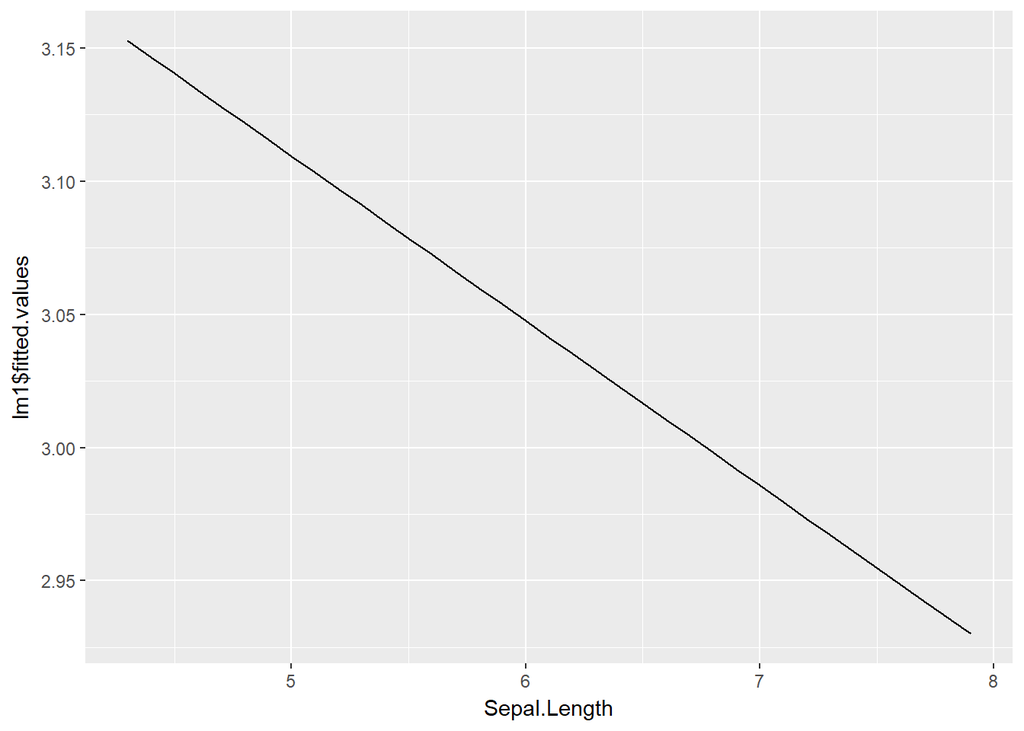

```r
ggplot(data = data) +
  geom_line(mapping = aes(x = Sepal.Length, y = lm1$fitted.values))
```

Kuvaajasta havaitaan negatiivinen korrelaatio selittäjän (Sepal.Length) ja vastemuuttujan (Sepal.Width) välillä.

Piirretään kuvaaja, jossa x= Sepal.Length ja y = mallin residuaalit.

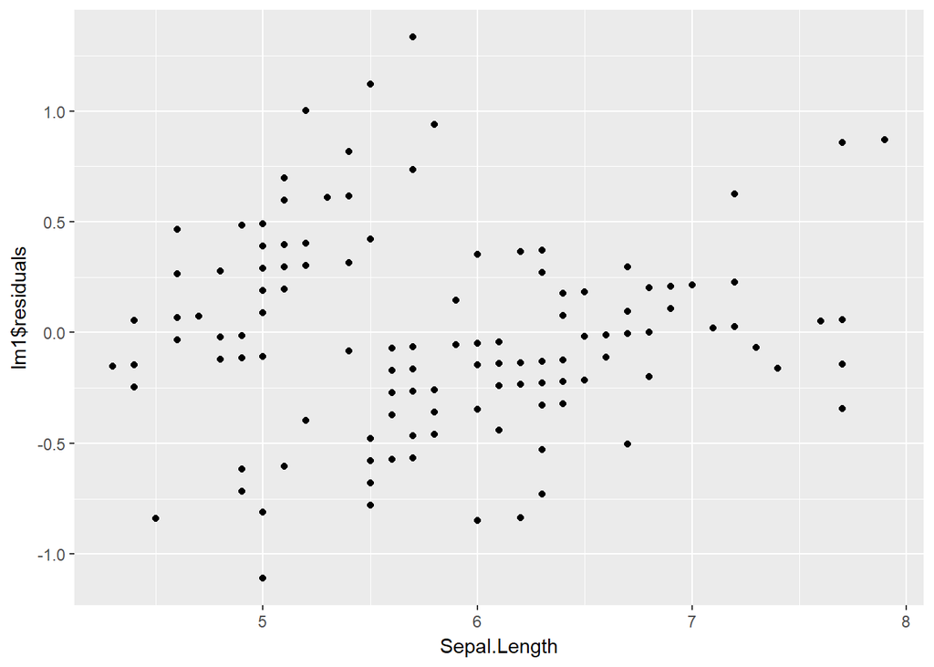

```r
ggplot(data = data) +
  geom_point(mapping = aes(x = Sepal.Length, y = lm1$residuals))
```

```r
library(lmtest)
bptest(lm1)
```

```
##
##  studentized Breusch-Pagan test
##
## data:  lm1
## BP = 2.7365, df = 1, p-value = 0.09808
```

Ylläolevan kuvan peruseella vakiovarianssi oletus näyttäisi pitävän paikkaansa. Varianssi on suurinpiirtein samanlaista koko havaintoalueella. Myös Breuch-Pagan- testin p-arvo 0.098 tukee vakiovarianssioletusta.

Lisätään Kurjenmiekkalaji selittäjäksi ja katsotaan paraneeko malli. Sovitetaan lineaarinen malli kahdella selittäjällä.

```r
lm2 <- lm(Sepal.Width~data$Sepal.Length+species)
summary(lm2)
```

```
##
## Call:
## lm(formula = Sepal.Width ~ data$Sepal.Length + species)
##
## Residuals:
##      Min       1Q   Median       3Q      Max
## -0.95096 -0.16522  0.00171  0.18416  0.72918
##
## Coefficients:
##                   Estimate Std. Error t value Pr(>|t|)
## (Intercept)        1.67650    0.23536   7.123 4.46e-11 ***
## data$Sepal.Length  0.34988    0.04630   7.557 4.19e-12 ***
## speciesversicolor -0.98339    0.07207 -13.644  < 2e-16 ***
## speciesvirginica  -1.00751    0.09331 -10.798  < 2e-16 ***
## ---
## Signif. codes:  0 '***' 0.001 '**' 0.01 '*' 0.05 '.' 0.1 ' ' 1
##
## Residual standard error: 0.289 on 146 degrees of freedom
## Multiple R-squared:  0.5693, Adjusted R-squared:  0.5604
## F-statistic: 64.32 on 3 and 146 DF,  p-value: < 2.2e-16
```

Piirretään kuvaaja, jossa x = Sepal.Length ja y = Sepal.Width. Lajit ovat eroteltu väreittäin

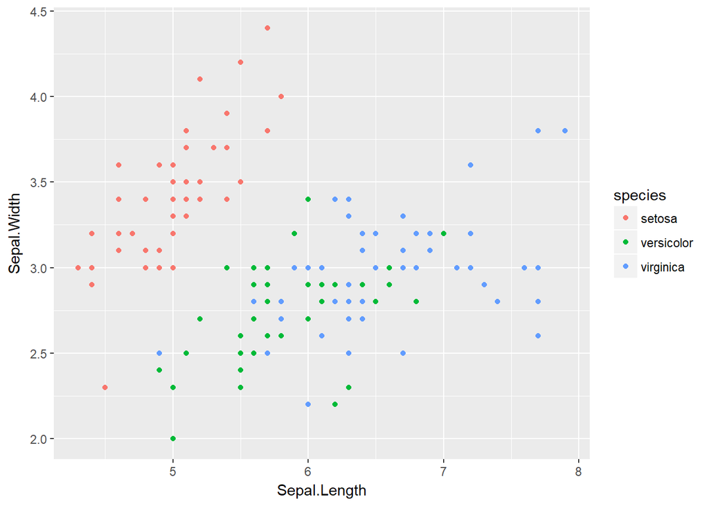

```r
ggplot(data = data) +
  geom_point(mapping = aes(x = Sepal.Length, y = Sepal.Width,color=species))
```

Ylläolevasta kuvasta nähdään, että eri lajit muodostavat omat ryhmänsä. Lisäksi nähdään positiivinen korrelaatio selittäjän ja vasteen välillä

Seuraavaksi piirretään kuvaaja, jossa x = Sepal.Length ja y = mallin sovitteet.

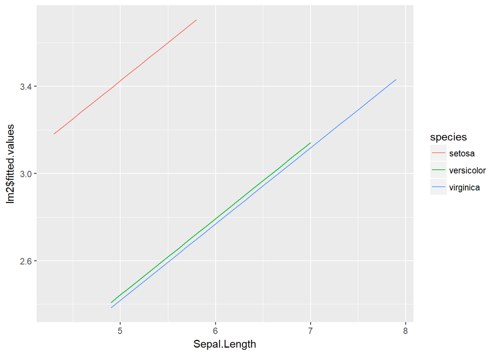

```r
ggplot(data = data) +
  geom_line(mapping = aes(x = Sepal.Length, y = lm2$fitted.values, color=species))
```

Kuvaajasta nähdään, että mallin sovitteet kulkevat eri tasoilla lajista riippuen.

Piirretään kuvaaja, jossa x= Sepal.Length ja y = mallin residuaalit.

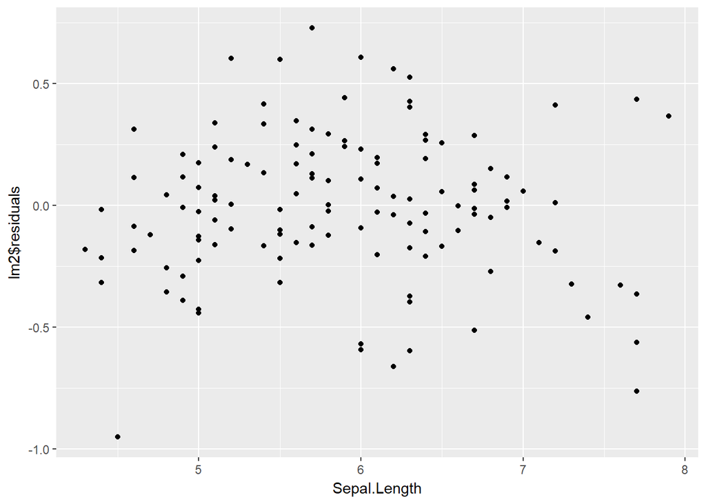

```r
ggplot(data = data) +
  geom_point(mapping = aes(x = Sepal.Length, y = lm2$residuals))
```

Vakiovarianssioletus näyttää tässäkin mallissa pitävän paikkaansa.

Testataan residuaalien normaalijakaumaoletus.

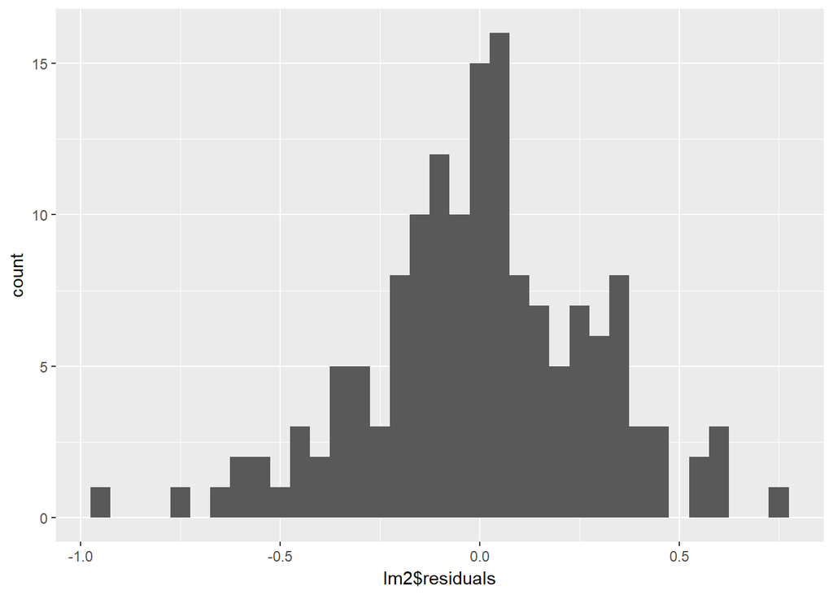

```r
ggplot(lm2, aes(lm2$residuals)) +
  geom_histogram(binwidth = 0.05)
```

```r
shapiro.test(lm2$residuals)
```

```
##
##  Shapiro-Wilk normality test
##
## data:  lm2$residuals
## W = 0.99066, p-value = 0.4248
```

Histogrammista nähdään, että residuaalit noudattavat suurinpiirtein normaalijakumaa. Shapiro-Wilk- testi tukee myös normaalijakaumaoletusta (p-arvo 0.4248).

Sovitetaan lineaarinen malli, johon lisätään selittäjien Sepa.Length ja species- muuttujien yhdysvaikutus.

```r
lm3 <- lm(Sepal.Width~Sepal.Length*species)
summary (lm3)
```

```
##
## Call:
## lm(formula = Sepal.Width ~ Sepal.Length * species)
##
## Residuals:
##      Min       1Q   Median       3Q      Max
## -0.72394 -0.16327 -0.00289  0.16457  0.60954
##
## Coefficients:
##                                Estimate Std. Error t value Pr(>|t|)
## (Intercept)                     -0.5694     0.5539  -1.028 0.305622
## Sepal.Length                     0.7985     0.1104   7.235 2.55e-11 ***
## speciesversicolor                1.4416     0.7130   2.022 0.045056 *
## speciesvirginica                 2.0157     0.6861   2.938 0.003848 **
## Sepal.Length:speciesversicolor  -0.4788     0.1337  -3.582 0.000465 ***
## Sepal.Length:speciesvirginica   -0.5666     0.1262  -4.490 1.45e-05 ***
## ---
## Signif. codes:  0 '***' 0.001 '**' 0.01 '*' 0.05 '.' 0.1 ' ' 1
##
## Residual standard error: 0.2723 on 144 degrees of freedom
## Multiple R-squared:  0.6227, Adjusted R-squared:  0.6096
## F-statistic: 47.53 on 5 and 144 DF,  p-value: < 2.2e-16
```

Mallin tulostukesta nähdään, että selittäjien yhdysvaikutus on mallissa tilastollisesti merkitsevä. Verholehden pituus vaikuttaa eri kulmakertoimella verholehden leveyteen, eri lajeilla.

Piirretään kuvaaja mallin sovitteista.

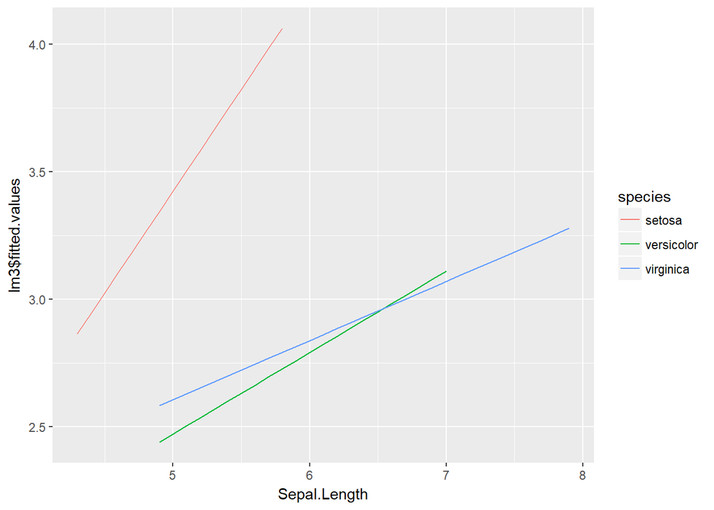

```r
ggplot(data = data) +
  geom_line(mapping = aes(x = Sepal.Length, y = lm3$fitted.values, color=species))
```

Sovitetaan vielä malli, jossa on selittäjinä kaikki aineiston muuttujat: Sepal.Length, Petal.Length, Petal.Width ja species.

```r
lm4 <- lm(Sepal.Width~Sepal.Length+Petal.Length+Petal.Width+species)
summary (lm4)
```

```
##
## Call:
## lm(formula = Sepal.Width ~ Sepal.Length + Petal.Length + Petal.Width +
##     species)
##
## Residuals:
##      Min       1Q   Median       3Q      Max
## -1.00102 -0.14786  0.00441  0.18544  0.69719
##
## Coefficients:
##                   Estimate Std. Error t value Pr(>|t|)
## (Intercept)        1.65716    0.25595   6.475 1.40e-09 ***
## Sepal.Length       0.37777    0.06557   5.761 4.87e-08 ***
## Petal.Length      -0.18757    0.08349  -2.246   0.0262 *
## Petal.Width        0.62571    0.12338   5.072 1.20e-06 ***
## speciesversicolor -1.16029    0.19329  -6.003 1.50e-08 ***
## speciesvirginica  -1.39825    0.27715  -5.045 1.34e-06 ***
## ---
## Signif. codes:  0 '***' 0.001 '**' 0.01 '*' 0.05 '.' 0.1 ' ' 1
##
## Residual standard error: 0.2678 on 144 degrees of freedom
## Multiple R-squared:  0.6352, Adjusted R-squared:  0.6225
## F-statistic: 50.14 on 5 and 144 DF,  p-value: < 2.2e-16
```

Tulostuksesta nähdään, että kaikki muuttujat ovat tilastollisesti merkitseviä selittäjiä.

Valitaan edellistä malleista paras käyttämällä Akaiken informaatiokriteeriä (AIC). Paras malli on se, jolla on pienin AIC- arvo.

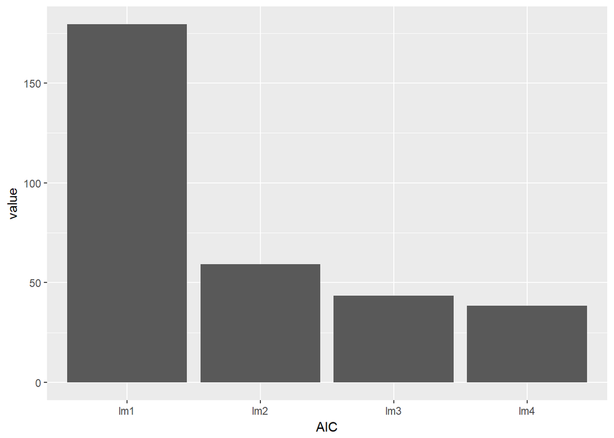

```r
df <- data.frame(AIC= c("lm1", "lm2", "lm3","lm4"), value = c(AIC(lm1),AIC(lm2), AIC(lm3),AIC(lm4)))
ggplot(df, aes(AIC, value)) +
  geom_col()
```

Pylväsdiagrammista nähdään, että Akaiken informaatiokriteerin mukaan paras malli on se, jossa on kaikki aineiston muuttujat selittäjinä (lm4) Em. mallilla on myös paras korjattu selitysaste (R-squared= 0.6225).